$x={-b \pm \sqrt{b^2 - 4ac} \over 2a}$ for $ax^2 + bx + c = 0$

# Python Basics

Library – Python uses libraries to enable users to perform tasks without writing codes from scratch. The libraries that are used in the Workshop are Math, Numpy and Matplotlib. Scipy is another useful library for scientific computing.

## 1. Math – https://docs.python.org/3/library/math.html

### Example 1a

```
from math import factorial
factorial(20)
```

### Example 1b

```
import math
math.factorial(20)
```

```python
from math import factorial
factorial(20)
```

```
2432902008176640000
```

```python
import math
math.factorial(20)
```

```
2432902008176640000
```

Example 1c – a short Python script to calculate using an equation

$k = Ae^{-E_a \over {RT}}$

${\ln} k = {\ln} A - {E_a \over {RT}}$

${E_a \over {RT}} = {\ln} A - {\ln} k$

${E_a} = {RT}({\ln} A - {\ln} k)$

```python
import math
R = 8.314 #in J per mol per K
T = 750 #in K
A = 1.86e15 #in per sec
k = 0.00018 #in per sec

Ea = R * T * (math.log(A) - math.log(k))

print ("The activation energy = " + str(Ea) + " J mol" + u'\u207B\u00B9')
```

```
The activation energy = 273002.0785401358 J mol⁻¹
```

### Question 1

(a) Write a script using math.factorial, math.log to calculate ${\ln} n!$, where $n$ is a 2-digit number of your choice.

```python
from math import factorial, log

n = 69

result = log(factorial(n))

print(f"ln(n!) = {result:.3f}")
```

```
ln(n!) = 226.191
```

(b) Copy the script above and add a line in your script to use the equation of Stirling’s approximation to calculate ${\ln} n!$

```python
from math import factorial, log

n = 69

stirlings_result = (n * log(n)) - n

print(f"ln(n!) ~ {stirlings_result:.3f}")
```

```
ln(n!) ~ 223.153
```

(c) Add another line to calculate the difference between the real value (a) and the approximated value. Calculate the %difference, which is the difference/real value * 100%.

```python
from math import factorial, log

n = 69

result = log(factorial(n))
stirlings_result = (n * log(n)) - n
perc_diff = 100 * abs(result - stirlings_result) / result

print(f"%diff = {perc_diff:.3f}")
```

```
%diff = 1.343
```

(d) Add two lines to print the following statements.

${\ln} n!$ is (the real value) and approximately (the approximated value) according to Stirling’s approximation.

The difference is (%difference) of the real value.

```python
from math import factorial, log

n = 69

result = log(factorial(n))
stirlings_result = (n * log(n)) - n
perc_diff = 100 * abs(result - stirlings_result) / result

print(f"ln(n!) is {result:.3f} and approximately {stirlings_result:.3f} according to Stirling's approximation.\nThe difference is {perc_diff:.3f}% of the real value.")
```

```
ln(n!) is 226.191 and approximately 223.153 according to Stirling's approximation.
The difference is 1.343% of the real value.
```

(e) Starting from (a) to (d), perform the tasks for (i) ${\ln} 100!$ and (ii) ${\ln}10000!$

```python
from math import factorial, log

n = 100

result = log(factorial(n))
stirlings_result = (n * log(n)) - n
perc_diff = 100 * abs(result - stirlings_result) / result

print(f"ln(n!) is {result:.3f} and approximately {stirlings_result:.3f} according to Stirling's approximation.\nThe difference is {perc_diff:.3f}% of the real value.")
```

```
ln(n!) is 363.739 and approximately 360.517 according to Stirling's approximation.
The difference is 0.886% of the real value.
```

```python
from math import factorial, log

n = 10000

result = log(factorial(n))
stirlings_result = (n * log(n)) - n
perc_diff = 100 * abs(result - stirlings_result) / result

print(f"ln(n!) is {result:.3f} and approximately {stirlings_result:.3f} according to Stirling's approximation.\nThe difference is {perc_diff:.3f}% of the real value.")
```

```
ln(n!) is 82108.928 and approximately 82103.404 according to Stirling's approximation.
The difference is 0.007% of the real value.
```

## 2. Numpy – https://numpy.org/doc/stable

### Example 2a – array

```
import numpy as np
a = np.array([1,2,3,4,5,6])
print("My first Python array is " + str(a))
```

### Example 2b – linearly spaced array

```
import numpy as np
b = np.linspace(0,50,51)
print("My first linearly spaced array in Python is " + str(a))
```

### Example 2c – zeros & ones

```
import numpy as np
c = np.zeros(5)
d = np.ones(5)
print(str(c) + str(d))
```

In your pre-workshop exercise, there is an example (In [34]) showing how square values can be calculated. In Python, exponents are expressed using ** (note that numpy is not needed for ** as it is a basic function). For example, 2**2 is 4 (try it) and 3**3 is 27.

```python
print(2 ** 2)
print(3 ** 3)
```

```
4
27
```

### Question 2

(a) Use numpy to create a linearly space array of even numbers ranging from 0 to 50 (i.e., [0. 2. 4. 6. …… 50.]. Show your work.

```python
import numpy as np
start = 0
stop = 50
num_values = int((stop / 2) + 1)
result = np.linspace(start, stop, num_values)
print(result)
```

```
[ 0.  2.  4.  6.  8. 10. 12. 14. 16. 18. 20. 22. 24. 26. 28. 30. 32. 34.
 36. 38. 40. 42. 44. 46. 48. 50.]
```

(b) Use numpy to create an array of 51 ones. Then, add this array to Array b (from Example 2b) to form a new array that ranges from 1 to 51 (i.e., [1. 2. 3. 4. …… 51.]. Show your work.

```python
import numpy as np
a = np.ones(51)
b = np.linspace(0,50,51)
result = a + b
print(result)
```

```
[ 1.  2.  3.  4.  5.  6.  7.  8.  9. 10. 11. 12. 13. 14. 15. 16. 17. 18.
 19. 20. 21. 22. 23. 24. 25. 26. 27. 28. 29. 30. 31. 32. 33. 34. 35. 36.
 37. 38. 39. 40. 41. 42. 43. 44. 45. 46. 47. 48. 49. 50. 51.]
```

(c) Use the ** function to create a new array with values that are squares of those of Array b, i.e., [0. 1. 4. 9. 16. …… 2500.]. Show your work.

```python
import numpy as np
a = np.ones(51)
b = np.linspace(0,50,51)
qb_result = a + b
qc_result = b ** 2
print(qc_result)
```

```
[0.000e+00 1.000e+00 4.000e+00 9.000e+00 1.600e+01 2.500e+01 3.600e+01
 4.900e+01 6.400e+01 8.100e+01 1.000e+02 1.210e+02 1.440e+02 1.690e+02
 1.960e+02 2.250e+02 2.560e+02 2.890e+02 3.240e+02 3.610e+02 4.000e+02
 4.410e+02 4.840e+02 5.290e+02 5.760e+02 6.250e+02 6.760e+02 7.290e+02
 7.840e+02 8.410e+02 9.000e+02 9.610e+02 1.024e+03 1.089e+03 1.156e+03
 1.225e+03 1.296e+03 1.369e+03 1.444e+03 1.521e+03 1.600e+03 1.681e+03
 1.764e+03 1.849e+03 1.936e+03 2.025e+03 2.116e+03 2.209e+03 2.304e+03
 2.401e+03 2.500e+03]
```

## 3. Matplotlib – https://matplotlib.org/stable/index.html

### Example 3a – making a linear plot

```
import numpy as np
b = np.linspace(0,50,51)
c = b
import matplotlib.pyplot as plt
plt.figure(figsize=(8,6))
plt.plot(b,c,'o',label="linear")
plt.xlabel("x")
plt.ylabel("y")
plt.legend()
```

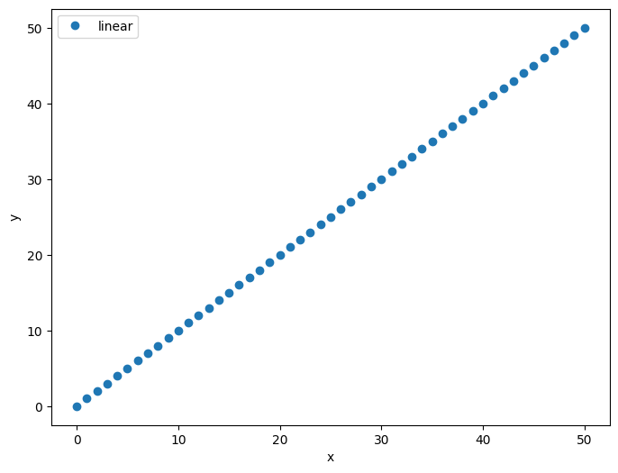

```python
import numpy as np
b = np.linspace(0,50,51)
c = b
import matplotlib.pyplot as plt
plt.figure(figsize=(8,6))
plt.plot(b,c,'o',label="linear")
plt.xlabel("x")
plt.ylabel("y")
plt.legend()
```

Spot the difference – rerun the code above by replacing line 6 with:

```
plt.plot(b,c,'o-',label="linear")
```

```
plt.plot(b,c,'ro-',label="linear")
```

```
plt.plot(b,c,'gx',label="linear")
```

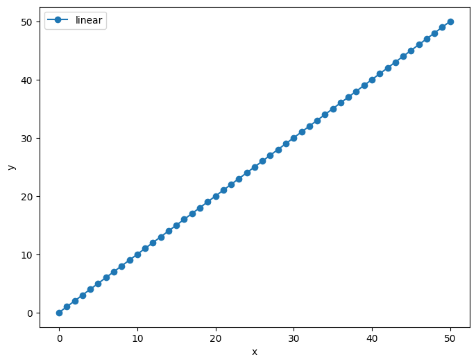

```python
import numpy as np
b = np.linspace(0,50,51)
c = b
import matplotlib.pyplot as plt
plt.figure(figsize=(8,6))
plt.plot(b,c,'o-',label="linear")
plt.xlabel("x")
plt.ylabel("y")
plt.legend()
```

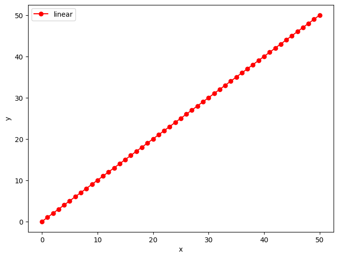

```python
import numpy as np
b = np.linspace(0,50,51)
c = b
import matplotlib.pyplot as plt
plt.figure(figsize=(8,6))
plt.plot(b,c,'ro-',label="linear")
plt.xlabel("x")
plt.ylabel("y")
plt.legend()
```

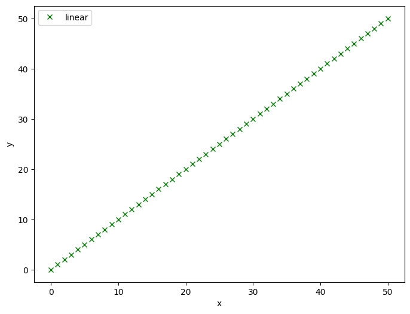

```python
import numpy as np
b = np.linspace(0,50,51)
c = b
import matplotlib.pyplot as plt
plt.figure(figsize=(8,6))
plt.plot(b,c,'gx',label="linear")
plt.xlabel("x")
plt.ylabel("y")
plt.legend()
```

### Question 3

(a) The plot above has a slope of 1. Modify the codes above to make a plot with a slope of 2. Make the size of the plot 10,10. Label the x-axis as “Number” and y-axis as “Intensity”. Show the data points as magenta crosses and connect the data points using a dotted line. Provide a legend that states “Magenta linear dots”.

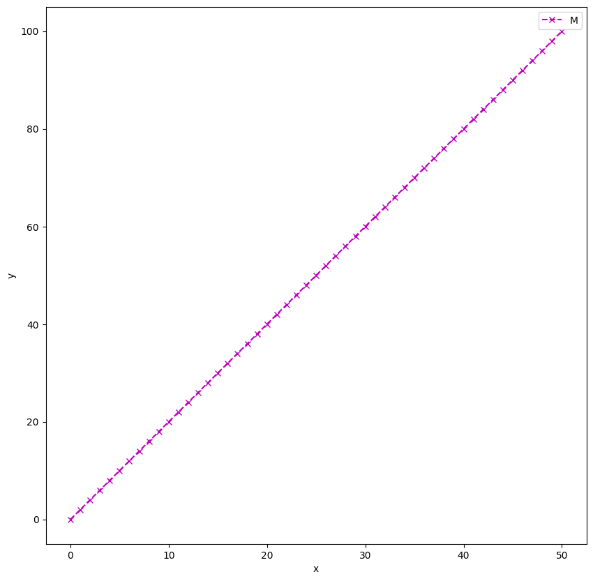

```python
import numpy as np
b = np.linspace(0,50,51)
c = 2 * b
import matplotlib.pyplot as plt
plt.figure(figsize=(10,10))
plt.plot(b,c, "mx", linestyle = "--",label="linear")
plt.xlabel("x")
plt.ylabel("y")
plt.legend("Magenta linear dots")
```

### Example 3b – loading data to make a plot

Download the files abs.csv & fluor.csv and upload them to this working directory.

```
import pandas as pd
dataframe = pd.read_csv("abs.csv", header=None)
data = dataframe.values
x, y = data[:,0], data[:,1]
import matplotlib.pyplot as plt
plt.figure(figsize=(8,6))
plt.plot(x,y,'b-',label="Abs")
plt.xlabel("x")
plt.ylabel("y")
plt.legend()
```

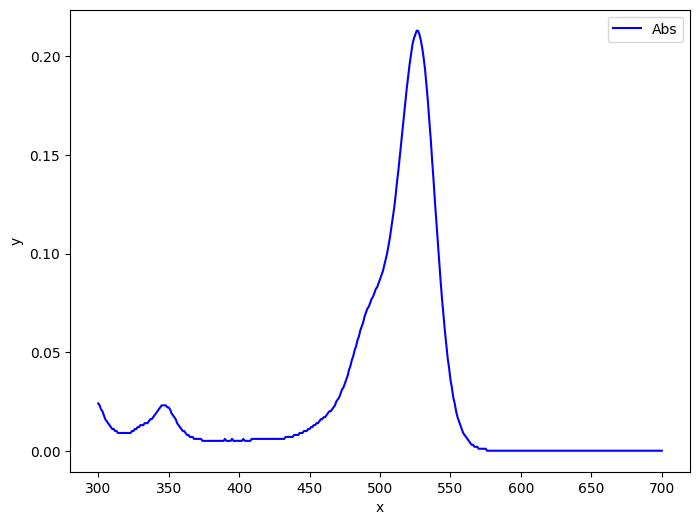

```python
import pandas as pd
dataframe = pd.read_csv("abs.csv", header=None)
data = dataframe.values
x, y = data[:,0], data[:,1]
import matplotlib.pyplot as plt
plt.figure(figsize=(8,6))
plt.plot(x,y,'b-',label="Abs")
plt.xlabel("x")
plt.ylabel("y")
plt.legend()
```

```
x, y = data[:,0], data[:,1]/max(data[:,1])
```

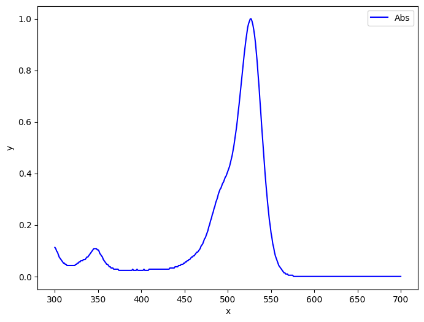

```python
import pandas as pd
dataframe = pd.read_csv("abs.csv", header=None)
data = dataframe.values
x, y = data[:,0], data[:,1]/max(data[:,1])
import matplotlib.pyplot as plt
plt.figure(figsize=(8,6))
plt.plot(x,y,'b-',label="Abs")
plt.xlabel("x")
plt.ylabel("y")
plt.legend()
```

What is the difference with this modification? What does the max function do?

*Your* comments:

```python
#Normalises the curve so that max value is 1. Max function returns the maximum vaue in the array.
```

Next, remove

```
/max(data[:,1])
```

from the line, replace *abs.csv* with *fluor.csv*, label the plot *“Fluor”* and run the code.

[figure not shown]

```python
import pandas as pd
dataframe = pd.read_csv("fluor.csv", header=None)
data = dataframe.values
x, y = data[:,0], data[:,1]
import matplotlib.pyplot as plt
plt.figure(figsize=(8,6))
plt.plot(x,y,'b-',label="Fluor")
plt.xlabel("x")
plt.ylabel("y")
plt.legend()
```

Once again, note the maximum y-value and use the max function on the y-data of *fluor.csv*

[figure not shown]

```python
import pandas as pd
dataframe = pd.read_csv("fluor.csv", header=None)
data = dataframe.values
x, y = data[:,0], data[:,1]/max(data[:,1])
import matplotlib.pyplot as plt
plt.figure(figsize=(8,6))
plt.plot(x,y,'b-',label="Fluor")
plt.xlabel("x")
plt.ylabel("y")
plt.legend()
```

Question 3(b) Plot both sets of data with a y-maximum of 1 in one plot by using the hints below.

(i) Use two distinct variables (e.g. dataframe1 & dataframe2) to name the strings from abs.csv and fluor.csv (ii) use the same approach for the next step, which defines the values of the read strings (iii) define the additional x, y values (e.g. x2, y2) (iv) make the y-maximum value 1 using the example above (v) add an additional line to add the second set of data, e.g. plt.plot(x2,y2,'r-',label="Fluor") (vi) Make the absorption curve blue (solid line) and fluorescence curve red (vii) Label the x-axis as “Wavelength (nm)” and y-axis as “Normalised absorbance or fluorescence.

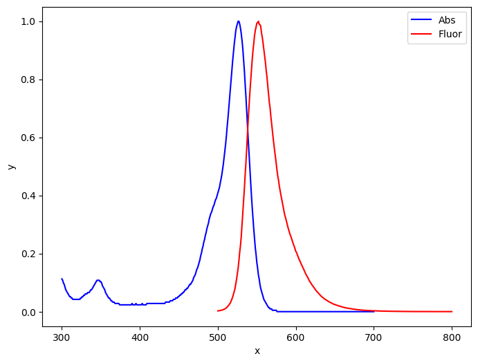

```python
import pandas as pd
dataframe1 = pd.read_csv("abs.csv", header=None)
dataframe2 = pd.read_csv("fluor.csv", header=None)
data1, data2 = dataframe1.values, dataframe2.values
x1, y1 = data1[:,0], data1[:,1]/max(data1[:,1])
x2, y2 = data2[:,0], data2[:,1]/max(data2[:,1])
import matplotlib.pyplot as plt
plt.figure(figsize=(8,6))
plt.plot(x1,y1,'b-',label="Abs")
plt.plot(x2,y2,'r-',label="Fluor")
plt.xlabel("x")
plt.ylabel("y")
plt.legend()
```

Question 3(c) Download carpathite.csv & dawsonite.csv, load them in Python, plot both sets of data (blue and red) with normalised intensity (maximum y-value of 1) in the same plot. Label the y-axis “Normalised intensity” and x-axis “Raman shift (cm$^{-1}$)”

Hint: use *(cm$^{-1}$)* in your x-axis label.

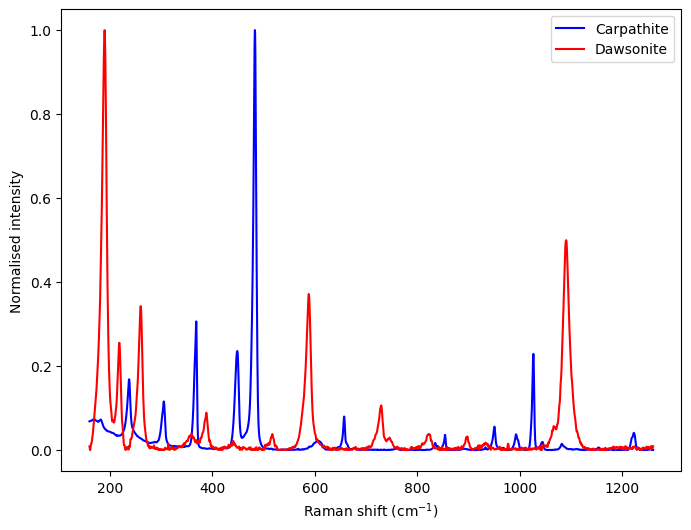

```python
import pandas as pd
dataframe1 = pd.read_csv("carpathite.csv", header=None)
dataframe2 = pd.read_csv("dawsonite.csv", header=None)
data1, data2 = dataframe1.values, dataframe2.values
x1, y1 = data1[:,0], data1[:,1]/max(data1[:,1])
x2, y2 = data2[:,0], data2[:,1]/max(data2[:,1])
import matplotlib.pyplot as plt
plt.figure(figsize=(8,6))
plt.plot(x1,y1,'b-',label="Carpathite")
plt.plot(x2,y2,'r-',label="Dawsonite")
plt.xlabel("Raman shift (cm$^{-1}$)")
plt.ylabel("Normalised intensity")
plt.legend()
```

## 4. Scipy – https://www.scipy.org

# Example 4a - curve fitting

Spend ~10 minutes to understand the code

```
import matplotlib.pyplot as plt
import numpy as np
import scipy.optimize as sp

def func(x, a, b, c):
    return a * np.exp(-b * x) + c

#Generate the data to be fit with some noise:
xdata = np.linspace(0, 4, 50)
y = func(xdata, 2.5, 1.3, 0.5)
np.random.seed(1729)
y_noise = 0.1 * np.random.normal(size=x_data.size)
ydata = y + y_noise

plt.figure(figsize=(8,6))
plt.plot(x_data, ydata, 'bo', mfc='none', label='data')

#Fit1: fit for the parameters a, b, c of the function func:
popt, pcov = sp.curve_fit(func, x_data, ydata)
#popt is the array of the optimised values and pcov contains the estimated covariance of popt

plt.plot(xdata, func(xdata, *popt), 'r-',
         label='fit: a=%.3f, b=%5.3f, c=%5.3f' % tuple(popt))

#Fit2: constrain the optimization to the region of 0 <= a <= 3, 0 <= b <= 1 and 0 <= c <= 0.5:
popt, pcov = sp.curve_fit(func, xdata, ydata, bounds=([0.0, 0.0, 0.0], [3.0, 1.0, 0.5]))

plt.plot(xdata, func(xdata, *popt), 'g--',
         label='fit: a=%5.3f, b=%5.3f, c=%5.3f' % tuple(popt))

plt.xlabel('x')
plt.ylabel('y')
plt.legend()
plt.show()
```

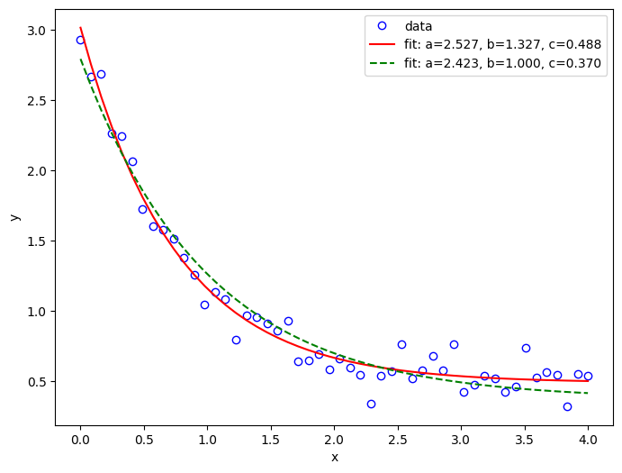

```python
import matplotlib.pyplot as plt
import numpy as np
import scipy.optimize as sp

def func(x, a, b, c):
    return a * np.exp(-b * x) + c

#Generate the data to be fit with some noise:
xdata = np.linspace(0, 4, 50)
y = func(xdata, 2.5, 1.3, 0.5)
np.random.seed(1729)
y_noise = 0.1 * np.random.normal(size=xdata.size)
ydata = y + y_noise

plt.figure(figsize=(8,6))
plt.plot(xdata, ydata, 'bo', mfc='none', label='data')

#Fit1: fit for the parameters a, b, c of the function func:
popt, pcov = sp.curve_fit(func, xdata, ydata)
#popt is the array of the optimised values and pcov contains the estimated covariance of popt

plt.plot(xdata, func(xdata, *popt), 'r-',
         label='fit: a=%.3f, b=%5.3f, c=%5.3f' % tuple(popt))

#Fit2: constrain the optimization to the region of 0 <= a <= 3, 0 <= b <= 1 and 0 <= c <= 0.5:
popt, pcov = sp.curve_fit(func, xdata, ydata, bounds=([0.0, 0.0, 0.0], [3.0, 1.0, 0.5]))

plt.plot(xdata, func(xdata, *popt), 'g--',
         label='fit: a=%5.3f, b=%5.3f, c=%5.3f' % tuple(popt))

plt.xlabel('x')
plt.ylabel('y')
plt.legend()
plt.show()
```

### Question 4

(a) Generate a code by using the following information.

(i) Define a linear function, $ax + b$ (use values other than $a=1$ and/or $b=0$.

(ii) Generate data ($x$ ranges from -10 to 10 with 101 points) with some noise (~10% of the maximum $y$ value).

(iii) Fit for the parameters $a, b$ of the function func.

(iv) Plot the data as red empty circles and fit curve as a black solid curve.

[figure not shown]

```python
import numpy as np
def lin_fn(x, a, b):
    result = a * x + b
    return result

x_data = np.linspace(-10, 10, 101)
y = lin_fn(x_data, 2, 3)
np.random.seed(1729)
y_noise = 0.1 * np.random.normal(size=x_data.size)
y_data = y + y_noise


plt.figure(figsize=(8,6))
plt.plot(x_data, y_data, 'ro', mfc='none', label='data')

# #Fit1: fit for the parameters a, b, c of the function func:
# popt, pcov = sp.curve_fit(lin_fn, x_data, y_data)
# #popt is the array of the optimised values and pcov contains the estimated covariance of popt

# plt.plot(x_data, lin_fn(x_data, *popt), 'r-',
#          label='fit: a=%.3f, b=%5.3f' % tuple(popt))

#Fit2: constrain the optimization to the region of 0 <= a <= 3, 0 <= b <= 1 and 0 <= c <= 0.5:
popt, pcov = sp.curve_fit(lin_fn, x_data, y_data, bounds=([0.0, 0.0], [2.0, 3.0]))

plt.plot(x_data, lin_fn(x_data, *popt), 'k',
         label='fit: a=%5.3f, b=%5.3f' % tuple(popt))

plt.xlabel('x')
plt.ylabel('y')
plt.legend()
plt.show()
```

Question 4(b) Generate a code by using the following information.

(i) Use the same linear function as above for this part.

(ii) Generate data ($x$ ranges from -10 to 10 with 101 points) with some noise ( only ~1% of the maximum $y$ value).

(iii) Fit for the parameters $a, b$ of the function func.

(iv) Plot the data as red empty circles and fit curve as a black solid curve.

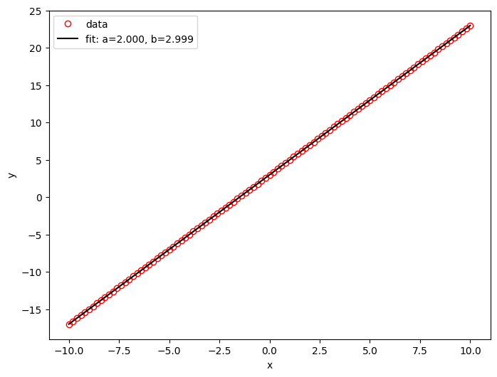

```python
import numpy as np
def lin_fn(x, a, b):
    result = a * x + b
    return result

x_data = np.linspace(-10, 10, 101)
y = lin_fn(x_data, 2, 3)
np.random.seed(1729)
y_noise = 0.01 * np.random.normal(size=x_data.size)
y_data = y + y_noise


plt.figure(figsize=(8,6))
plt.plot(x_data, y_data, 'ro', mfc='none', label='data')

## Fit1: fit for the parameters a, b, c of the function func:
# popt, pcov = sp.curve_fit(lin_fn, x_data, y_data)
# popt is the array of the optimised values and pcov contains the estimated covariance of popt

# plt.plot(x_data, lin_fn(x_data, *popt), 'r-',
         # label='fit: a=%.3f, b=%5.3f' % tuple(popt))

#Fit2: constrain the optimization to the region of 0 <= a <= 3, 0 <= b <= 1 and 0 <= c <= 0.5:
popt, pcov = sp.curve_fit(lin_fn, x_data, y_data, bounds=([0.0, 0.0], [2.0, 3.0]))

plt.plot(x_data, lin_fn(x_data, *popt), 'k',
         label='fit: a=%5.3f, b=%5.3f' % tuple(popt))

plt.xlabel('x')
plt.ylabel('y')
plt.legend()
plt.show()
```

Provide a brief comment on the effect of less noise on the fit results.

Your comment:

```python
#Less noise results in approximated a and b values to be closer to actual value e.g b = 2.999 vs 2.993
```

Question 4(c) Generate a code by using the following information.

(i) Define a quadratic function using variables $a, b$ and $c$.

(ii) Generate data ($x$ ranges from -10 to 10 with 101 points) with some noise (~10% of the maximum $y$ value).

(iii) Fit for the parameters $a, b, c$ of the function func.

(iv) Plot the data as blue circles and fit curve as a black curve.

[figure not shown]

```python
import numpy as np
def quad_fn(x, a, b, c):
    result = a * (x ** 2) + (b * x) + c
    return result

x_data = np.linspace(-10, 10, 101)
y = quad_fn(x_data, 2, 3, 5)
np.random.seed(1729)
y_noise = 0.1 * np.random.normal(size=x_data.size)
y_data = y + y_noise


plt.figure(figsize=(8,6))
plt.plot(x_data, y_data, 'bo', mfc='none', label='data')

# #Fit1: fit for the parameters a, b, c of the function func:
# popt, pcov = sp.curve_fit(quad_fn, x_data, y_data)
# #popt is the array of the optimised values and pcov contains the estimated covariance of popt

# #plt.plot(x_data, quad_fn(x_data, *popt), 'r-',
#          #label='fit: a=%.3f, b=%5.3f, c=%5.3f' % tuple(popt))

#Fit2: constrain the optimization to the region of 0 <= a <= 3, 0 <= b <= 1 and 0 <= c <= 0.5:
popt, pcov = sp.curve_fit(quad_fn, x_data, y_data, bounds=([0.0, 0.0, 0.0], [2.0, 3.0, 5.0]))

plt.plot(x_data, quad_fn(x_data, *popt), 'k',
         label='fit: a=%5.3f, b=%5.3f, c=%5.3f' % tuple(popt))

plt.xlabel('x')
plt.ylabel('y')
plt.legend()
plt.show()
```